# The analysis of compositional data in soil science with `R`

Serge-Étienne Parent

Montréal, 5th of July, 2015

# What

**R** is a modular open source statistical programming environment mainly used for data analysis and plotting. It can be used for classical statistics, data mining and machine learning in a large range of fields: ecology, economy, geography, demography, climatology, and… soils!

# Why

- Open source
- Expandable
- Reproducible
- Popular
- Fun (no, really!)

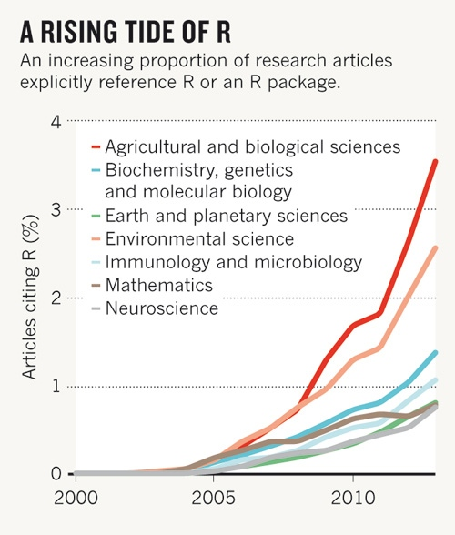

[Source: Programming tools: Adventures with R, Nature toolbox](http://www.nature.com/news/programming-tools-adventures-with-r-1.16609)

# Resources

*Help*:

- No official, formal, centralized support team… but a large community of experts
- Search engine: http://rseek.org/
- StackOverflow: http://stackoverflow.com/questions/tagged/r
- CrossValidated: http://stats.stackexchange.com/questions/tagged/r
- Mailing lists: http://www.r-project.org/mail.html
- https://stat.ethz.ch/mailman/listinfo/r-sig-ecology
- https://stat.ethz.ch/mailman/listinfo/r-sig-geo
- serge-etienne.parent.1@ulaval.ca

*Other*:

- R blogs: http://www.r-bloggers.com/
- Resources proposed by the California soil resource laboratory: http://casoilresource.lawr.ucdavis.edu/software/r-advanced-statistical-package/

# `R` basics

> “Freedom is the freedom to say that two plus two make four. If that is granted, all else follows.” - George Orwell

```r
2 + 2
```

```
## [1] 4
```

<- is assign. = could also be used, but it is generally reserved for asigning arguments in functions. Asing a numeric value:

```r
x <- 2 + 2
x
```

```
## [1] 4
```

`numeric` is a data class. There are other classes, like `character`:

```r
favoriteAnimal <- 'Jackalope' # comment: you can use ' ' or " "
favoriteAnimal
```

```
## [1] "Jackalope"
```

The `factor` class:

```r
soilOrder <-  factor(c("Brunisolic", "Chernozemic", "Organic", "Podzolic", "Unclassified"))
soilOrder
```

```
## [1] Brunisolic   Chernozemic  Organic      Podzolic     Unclassified
## Levels: Brunisolic Chernozemic Organic Podzolic Unclassified
```

The boolean, or `logical` class:

```r
isR <- TRUE
isR
```

```
## [1] TRUE
```

`function` class:

```r
powerRanger <- function(x, power) {
  y <- range(x^power) # range is a built in function
  return(y)
}
powerRanger(x = seq(from = 2, to = 10, by = 1), power = 2) # x is a vector, seq is a built in function
```

```
## [1]   4 100
```

## Vector and matrices

Vectors and matrices are containers for a single data class:

```r
vectorNum <- c(2, 6, 1, 7, 8)
vectorNum
```

```
## [1] 2 6 1 7 8
```

```r
vectorChar <- c(2, 6, 'coffee', 7, 8)
vectorChar
```

```
## [1] "2"      "6"      "coffee" "7"      "8"
```

```r
vectorFactor <- factor(c('tea', 'tea', 'coffee', 'water', 'tea'))
vectorFactor
```

```
## [1] tea    tea    coffee water  tea
## Levels: coffee tea water
```

```r
matrixNum <- matrix(c(1, 1,-1,
                      1,-1, 0),
                    byrow = TRUE,
                    ncol = 3)
matrixNum
```

```
##      [,1] [,2] [,3]
## [1,]    1    1   -1
## [2,]    1   -1    0
```

## Lists and data frames

Lists (`list`) are collections of heterogeneous data. They are very useful to store function outputs in loops, like the output of anovas or linear regressions. Data frames (`data.frame`) is a list of vectors with equal length. They are used for handling tables.

```r
listOfThings <- list(order = factor(c("Brunisolic", "Chernozemic", "Organic", "Podzolic", "Unclassified")),
                     numValues = c(2, 4, 1),
                     description = 'This list contain uninformative things.')
listOfThings
```

```
## $order
## [1] Brunisolic   Chernozemic  Organic      Podzolic     Unclassified
## Levels: Brunisolic Chernozemic Organic Podzolic Unclassified
##
## $numValues
## [1] 2 4 1
##
## $description
## [1] "This list contain uninformative things."
```

```r
listOfThings$order
```

```
## [1] Brunisolic   Chernozemic  Organic      Podzolic     Unclassified
## Levels: Brunisolic Chernozemic Organic Podzolic Unclassified
```

```r
soilTable <- data.frame(order = factor(c("Brunisolic", "Chernozemic", "Organic", "Podzolic", "Unclassified", "Organic")),
                        var1 = rnorm(6, 2, 4),
                        var2 = runif(6, 0, 10))
soilTable
```

```
##          order      var1     var2
## 1   Brunisolic -1.619385 6.737198
## 2  Chernozemic -1.426986 1.678111
## 3      Organic  4.570728 2.929421
## 4     Podzolic  9.817715 9.891040
## 5 Unclassified  3.093265 3.979621
## 6      Organic  4.149057 2.915609
```

```r
soilTable$order
```

```
## [1] Brunisolic   Chernozemic  Organic      Podzolic     Unclassified
## [6] Organic
## Levels: Brunisolic Chernozemic Organic Podzolic Unclassified
```

## RStudio

**R** can be used with only a terminal and a text editor, but GUIs are useful. I highly recommend **RStudio**, an open source interface for **R** developed and supported by an eponym commercial enterprise. It can be downloaded from: http://www.rstudio.com/.

[figure not shown]

Other interfaces: RGUI (default in Windows versions of R), [Jupyter](http://jupyter.org/), RCommander, [RkWard (Linux only)](https://rkward.kde.org/), [Deducer](http://www.deducer.org/pmwiki/pmwiki.php?n=Main.DeducerManual), [JGR](http://rforge.net/JGR/), etc.

## Importing data in `R`

Built in data:

```r
data(cars)
summary(cars)
```

```
##      speed           dist
##  Min.   : 4.0   Min.   :  2.00
##  1st Qu.:12.0   1st Qu.: 26.00
##  Median :15.0   Median : 36.00
##  Mean   :15.4   Mean   : 42.98
##  3rd Qu.:19.0   3rd Qu.: 56.00
##  Max.   :25.0   Max.   :120.00
```

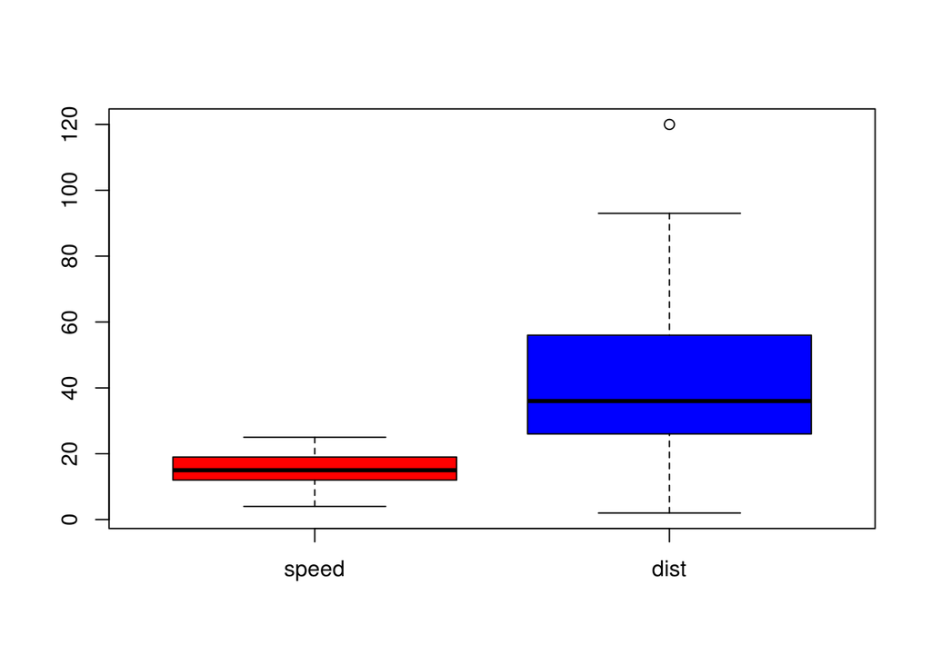

```r
boxplot(cars, col = c('red', 'blue'))
```

Import data:

```r
data <- read.csv("data/mango.csv", sep = ";", dec = ".", header = TRUE)
```

## Operations

### Selection (columns) and filter (rows)

```r
dataHead <- head(data)
dataHead
```

```
##   Echantillon Meme.echantilon.qui.recolte.2009.2010                Ville
## 1         185                                    63         Taquaritinga
## 2         186                                    64         Taquaritinga
## 3           7                                    NA              Pirangi
## 4         142                                    85 Vista Alegre do Alto
## 5         208                                    35     Fernando Prestes
## 6         183                                    61         Taquaritinga
##     Recolte Cultivar  Age Espacement.m Aplicacion.PBZ.ml.do.p.a..plante
## 1 2010/2011    Tommy 2002     10 x 3,5                             4.50
## 2 2010/2011    Tommy 2002       10 x 6                             5.00
## 3 2009/2010   Palmer 2000        8 x 5                             1.80
## 4 2010/2011   Palmer 1997        7 x 5                             2.70
## 5 2010/2011   Palmer 2000        8 x 6                             2.00
## 6 2010/2011    Tommy 1983      12 x 10                             5.25
##   SPAD_m Irrigation.I.NI rdt.kg.Plante sol.pH.cacl2 sol.M.O.g.dm3
```

[output cut: 48 more lines]

```r
dataHead[3, ] # filter row 3
```

```
##   Echantillon Meme.echantilon.qui.recolte.2009.2010   Ville   Recolte
## 3           7                                    NA Pirangi 2009/2010
##   Cultivar  Age Espacement.m Aplicacion.PBZ.ml.do.p.a..plante SPAD_m
## 3   Palmer 2000        8 x 5                              1.8   58.1
##   Irrigation.I.NI rdt.kg.Plante sol.pH.cacl2 sol.M.O.g.dm3 sol.P.mg.dm3
## 3              NI         182.8          5.5            15           12
##   sol.K.mmolc.dm3 sol.Ca.mmolc.dm3 sol.Mg.mmolc.dm3 sol.H.Almmolc.dm3
## 3               1               17                7                16
##   sol.SB.mmolc.dm3 sol.T.mmolc.dm3 sol.V.perc sol.B.mg.dm3 sol.Cu.mg.dm3
## 3               25              41         61         0.06             6
##   sol.Fe.mg.dm3 sol.Mn.mg.dm3 sol.Zn.mg.dm3 sol.S.S04.mg.dm3
## 3            17            22           1.2                1
##   sol.Al.mmolc.dm3 fol.N.g.kg fol.P.g.kg fol.K.g.kg fol.Ca.g.kg
## 3                0       16.5          1        9.7        18.3
##   fol.Mg.g.kg fol.S.g.kg fol.B.mg.kg fol.Cu.mg.kg fol.Fe.mg.kg
## 3         2.5        1.3          41           12           43
##   fol.Mn.mg.kg fol.Zn.mg.kg
## 3          404           11
```

```r
dataHead[, 1] # select column 1
```

```
## [1] 185 186   7 142 208 183
```

```r
dataHead[, 1:3] # keep only columns 1 to 3 included. 1:3 is a shortcut for seq(from = 1, to = 3, by = 1)
```

```
##   Echantillon Meme.echantilon.qui.recolte.2009.2010                Ville
## 1         185                                    63         Taquaritinga
## 2         186                                    64         Taquaritinga
## 3           7                                    NA              Pirangi
## 4         142                                    85 Vista Alegre do Alto
## 5         208                                    35     Fernando Prestes
## 6         183                                    61         Taquaritinga
```

```r
dataHead[, -c(1:3)] # remove columns 1 to 3
```

```
##     Recolte Cultivar  Age Espacement.m Aplicacion.PBZ.ml.do.p.a..plante
## 1 2010/2011    Tommy 2002     10 x 3,5                             4.50
## 2 2010/2011    Tommy 2002       10 x 6                             5.00
## 3 2009/2010   Palmer 2000        8 x 5                             1.80
## 4 2010/2011   Palmer 1997        7 x 5                             2.70
## 5 2010/2011   Palmer 2000        8 x 6                             2.00
## 6 2010/2011    Tommy 1983      12 x 10                             5.25
##   SPAD_m Irrigation.I.NI rdt.kg.Plante sol.pH.cacl2 sol.M.O.g.dm3
## 1   46.7              NI         197.2          5.4            12
## 2   45.3              NI         185.4          5.7            10
## 3   58.1              NI         182.8          5.5            15
## 4   53.2              NI         172.6          5.6            12
## 5   49.5              NI         171.7          5.0            12
## 6   46.2              NI         171.5          6.0            14
##   sol.P.mg.dm3 sol.K.mmolc.dm3 sol.Ca.mmolc.dm3 sol.Mg.mmolc.dm3
```

[output cut: 41 more lines]

```r
dataHead$rdt.kg.Plante # $ for data.frames and lists, not matrices
```

```
## [1] 197.2 185.4 182.8 172.6 171.7 171.5
```

```r
dataHead[c('Cultivar', 'rdt.kg.Plante', 'sol.M.O.g.dm3')]
```

```
##   Cultivar rdt.kg.Plante sol.M.O.g.dm3
## 1    Tommy         197.2            12
## 2    Tommy         185.4            10
## 3   Palmer         182.8            15
## 4   Palmer         172.6            12
## 5   Palmer         171.7            12
## 6    Tommy         171.5            14
```

```r
dataHead[1:4, c('Cultivar', 'rdt.kg.Plante', 'sol.M.O.g.dm3')]
```

```
##   Cultivar rdt.kg.Plante sol.M.O.g.dm3
## 1    Tommy         197.2            12
## 2    Tommy         185.4            10
## 3   Palmer         182.8            15
## 4   Palmer         172.6            12
```

```r
colnames(dataHead)
```

```
##  [1] "Echantillon"
##  [2] "Meme.echantilon.qui.recolte.2009.2010"
##  [3] "Ville"
##  [4] "Recolte"
##  [5] "Cultivar"
##  [6] "Age"
##  [7] "Espacement.m"
##  [8] "Aplicacion.PBZ.ml.do.p.a..plante"
##  [9] "SPAD_m"
## [10] "Irrigation.I.NI"
## [11] "rdt.kg.Plante"
## [12] "sol.pH.cacl2"
## [13] "sol.M.O.g.dm3"
## [14] "sol.P.mg.dm3"
## [15] "sol.K.mmolc.dm3"
```

[output cut: 24 more lines]

### Math and stats

+, -, *, /, ^

```r
dataHead * 3 # multiply all cells by 3: makes no sense, but worth trying
```

```
##   Echantillon Meme.echantilon.qui.recolte.2009.2010 Ville Recolte Cultivar
## 1         555                                   189    NA      NA       NA
## 2         558                                   192    NA      NA       NA
## 3          21                                    NA    NA      NA       NA
## 4         426                                   255    NA      NA       NA
## 5         624                                   105    NA      NA       NA
## 6         549                                   183    NA      NA       NA
##    Age Espacement.m Aplicacion.PBZ.ml.do.p.a..plante SPAD_m
## 1 6006           NA                            13.50  140.1
## 2 6006           NA                            15.00  135.9
## 3 6000           NA                             5.40  174.3
## 4 5991           NA                             8.10  159.6
## 5 6000           NA                             6.00  148.5
## 6 5949           NA                            15.75  138.6
##   Irrigation.I.NI rdt.kg.Plante sol.pH.cacl2 sol.M.O.g.dm3 sol.P.mg.dm3
```

[output cut: 48 more lines]

```r
apply(dataHead[c('sol.K.mmolc.dm3', 'sol.Ca.mmolc.dm3')], 1, sum)
```

```
##    1    2    3    4    5    6
## 41.7 44.9 18.0 30.7 17.5 37.0
```

```r
apply(dataHead[c('sol.K.mmolc.dm3', 'sol.Ca.mmolc.dm3')], 2, mean)
```

```
##  sol.K.mmolc.dm3 sol.Ca.mmolc.dm3
##          2.30000         29.33333
```

```r
cov(dataHead[, c(29:39)])
```

```
##              fol.N.g.kg fol.P.g.kg   fol.K.g.kg fol.Ca.g.kg fol.Mg.g.kg
## fol.N.g.kg        2.243      0.074   0.42700000  -0.2380000  0.30100000
## fol.P.g.kg        0.074      0.004  -0.02400000  -0.0260000  0.00800000
## fol.K.g.kg        0.427     -0.024   1.70966667   1.5426667  0.03233333
## fol.Ca.g.kg      -0.238     -0.026   1.54266667   9.0426667 -0.32866667
## fol.Mg.g.kg       0.301      0.008   0.03233333  -0.3286667  0.07366667
## fol.S.g.kg       -0.119     -0.006  -0.03100000   0.2340000 -0.01300000
## fol.B.mg.kg       2.190      0.280  -9.58333333 -19.3133333  1.48333333
## fol.Cu.mg.kg    -52.390     -1.900 -23.29000000 -72.6800000 -3.47000000
## fol.Fe.mg.kg    -17.640     -1.120   7.15333333  34.4933333 -2.67333333
## fol.Mn.mg.kg     31.450      1.100 -80.71666667 -81.0066667 11.31666667
## fol.Zn.mg.kg     -5.050     -0.060  -7.55666667   0.2933333 -0.20333333
##              fol.S.g.kg fol.B.mg.kg fol.Cu.mg.kg fol.Fe.mg.kg fol.Mn.mg.kg
## fol.N.g.kg       -0.119    2.190000       -52.39   -17.640000     31.45000
## fol.P.g.kg       -0.006    0.280000        -1.90    -1.120000      1.10000
## fol.K.g.kg       -0.031   -9.583333       -23.29     7.153333    -80.71667
## fol.Ca.g.kg       0.234  -19.313333       -72.68    34.493333    -81.00667
## fol.Mg.g.kg      -0.013    1.483333        -3.47    -2.673333     11.31667
## fol.S.g.kg        0.027   -0.230000         2.31     3.120000      8.15000
## fol.B.mg.kg      -0.230  102.166667       115.10  -122.266667    569.63333
## fol.Cu.mg.kg      2.310  115.100000      2065.10   308.400000    929.90000
## fol.Fe.mg.kg      3.120 -122.266667       308.40   477.466667    327.26667
## fol.Mn.mg.kg      8.150  569.633333       929.90   327.266667  11414.16667
## fol.Zn.mg.kg      0.850   44.233333       151.30    43.066667    493.36667
##              fol.Zn.mg.kg
## fol.N.g.kg     -5.0500000
## fol.P.g.kg     -0.0600000
## fol.K.g.kg     -7.5566667
## fol.Ca.g.kg     0.2933333
## fol.Mg.g.kg    -0.2033333
## fol.S.g.kg      0.8500000
## fol.B.mg.kg    44.2333333
## fol.Cu.mg.kg  151.3000000
## fol.Fe.mg.kg   43.0666667
## fol.Mn.mg.kg  493.3666667
## fol.Zn.mg.kg   59.3666667
```

```r
dataHead$fol.Fv <- 1000 - apply(dataHead[, c(29:33)], 1, sum) # change values of a column
dataHead
```

```
##   Echantillon Meme.echantilon.qui.recolte.2009.2010                Ville
## 1         185                                    63         Taquaritinga
## 2         186                                    64         Taquaritinga
## 3           7                                    NA              Pirangi
## 4         142                                    85 Vista Alegre do Alto
## 5         208                                    35     Fernando Prestes
## 6         183                                    61         Taquaritinga
##     Recolte Cultivar  Age Espacement.m Aplicacion.PBZ.ml.do.p.a..plante
## 1 2010/2011    Tommy 2002     10 x 3,5                             4.50
## 2 2010/2011    Tommy 2002       10 x 6                             5.00
## 3 2009/2010   Palmer 2000        8 x 5                             1.80
## 4 2010/2011   Palmer 1997        7 x 5                             2.70
## 5 2010/2011   Palmer 2000        8 x 6                             2.00
## 6 2010/2011    Tommy 1983      12 x 10                             5.25
##   SPAD_m Irrigation.I.NI rdt.kg.Plante sol.pH.cacl2 sol.M.O.g.dm3
```

[output cut: 48 more lines]

## Basic plot

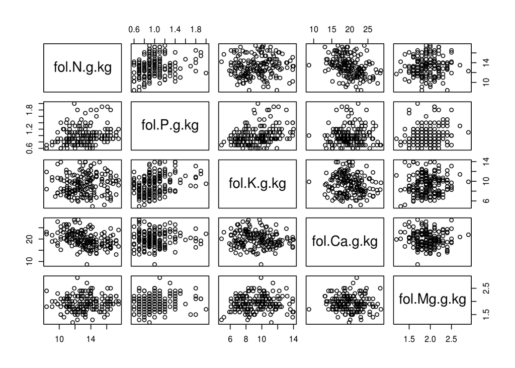

```r
plot(data[, c(29:33)])
```

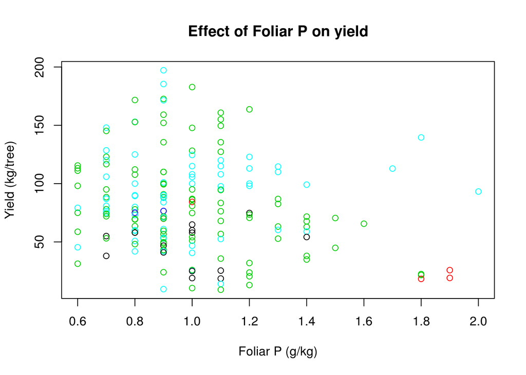

```r
plot(x = data$fol.P.g.kg, y = data$rdt.kg.Plante, col = data$Cultivar,
     main = "Effect of Foliar P on yield", xlab = "Foliar P (g/kg)", ylab = "Yield (kg/tree)") # col, the color, is defined by a factor column
```

## Install and load packages

Packages can be installed and loaded by using the “Packages” tab in RStudio. To install, click install and write the name of the package to install (internet connection needed). You can also use the function directly in the console. To load a package, you check the corresponding box. However, since you have to load your packages at each session, it is easier to specify the packages to load in your code.

```r
# install.packages('nortest')
library(nortest)
```

Suggested packages (nonexhaustive):

- `ade4` and `vegan` for ecological analysis
- `aqp` for pedology analysis
- `caret` for machine learning
- `compositions` for CoDa
- `dplyr` a new way to work with `R`
- `ggplot2` high quality plots, including maps
- `gstat` for geostatistics
- `ggtern` ggplot for ternary diagrams
- `meta` and `metafor` for meta-analysis
- `mvoutlier` for outlier detection
- `reshape2` organize data for `ggplot2`
- `robCompositions` robust imputations for CoDa
- `soiltexture` for guess what
- `zCompositions` for handling zeros in CoDa

# CoDa in `R`

## Preprocessing: Exploration of our data set and prepare for analysis

Compositional data sets must be free of missing values and zeros. Both can be imputed in `R` without prior data transformation, because packages `robCompositions` (missing values) and `zCompositions` (zeros) already include CoDa compliant procedures. On the other hand, outlier detection routines must be run across transformed values.

### Variables to consider as parts of the simplex

```r
varLeaf <- c("fol.N.g.kg", "fol.P.g.kg", "fol.K.g.kg", "fol.Ca.g.kg", "fol.Mg.g.kg") # make sure units are consistent!)
parts <- data[varLeaf]
```

The data set is exempt of any zeros or missing values. Let’s **replace small values by zeros**.

```r
apply(parts, 2, min)
```

```
##  fol.N.g.kg  fol.P.g.kg  fol.K.g.kg fol.Ca.g.kg fol.Mg.g.kg
##         8.4         0.6         4.9         8.7         1.2
```

We could assume, for this tutorial, that detection limit is 0.7 for all parts,

```r
parts[parts < 0.7] <- 0
apply(parts, 2, min)
```

```
##  fol.N.g.kg  fol.P.g.kg  fol.K.g.kg fol.Ca.g.kg fol.Mg.g.kg
##         8.4         0.0         4.9         8.7         1.2
```

```r
sum(parts == 0) # in a Boolean sum, a FALSE is 0 and TRUE is 1. The sum is the number of TRUEs
```

```
## [1] 9
```

```r
countZero <- function(x) {
  sum(x == 0, na.rm = TRUE)
}

# number of zeros per column
apply(parts, 2, countZero)
```

```
##  fol.N.g.kg  fol.P.g.kg  fol.K.g.kg fol.Ca.g.kg fol.Mg.g.kg
##           0           9           0           0           0
```

```r
# lines where at least one zero is encountered
isZeroRow <- apply(parts, 1, function(x) any(x == 0, na.rm = TRUE))
```

There are now some zeros in the P column. Now, let’s **add missing values (NA)**.

```r
set.seed(7) # to make sure every random run returns the same result

nbNA <- 10
for (i in 1:nbNA) {
  parts[sample(x = 1:nrow(parts), size = 1),
     sample(x = 1:ncol(parts), size = 1)] <- NA
}

countNA <- function(x) {
  sum(is.na(x), na.rm = TRUE)
}

# number of zeros per column
apply(parts, 2, countNA)
```

```
##  fol.N.g.kg  fol.P.g.kg  fol.K.g.kg fol.Ca.g.kg fol.Mg.g.kg
##           3           2           2           1           2
```

```r
# lines where at least one zero is encountered
isNaRow <- apply(parts, 1, function(x) any(is.na(x), na.rm = TRUE))
```

### Missing values

The script to impute missing value doesn’t like zeros. We remove the lines tagged with a `TRUE` value in the `isZeroRow` vector.

```r
library(robCompositions)
partsNA <- parts
partsNA[!isZeroRow, ] <- impKNNa(parts[!isZeroRow, ], method = 'knn', k = 3, metric = 'Aitchison')$xImp # ! inverses a Boolean and $xImp gets the imputed matrix

anyNA(partsNA)
```

```
## [1] FALSE
```

```r
rbind(parts[isNaRow, ][1, ], partsNA[isNaRow, ][1, ])
```

```
##    fol.N.g.kg fol.P.g.kg fol.K.g.kg fol.Ca.g.kg fol.Mg.g.kg
## 2        13.5        0.9         NA        18.3         2.1
## 21       13.5        0.9   6.876316        18.3         2.1
```

This procedure can’t be applied on lines containing both at least a zero and at least a missing value. If that row is not so important, you might remove it. If it is, you might first impute the zero as a fraction of 65% of the detection limit.

### Zeros

Three kind of zeroes can be identified:

- Rounded zeroes: concentration below detection limit
- Count zeroes: undetected count data (sample size too small)
- Essential zero: true zero. ** Observed termites in permafrost or diamonds in podzols or votes for the Bloc québécois in Calgary-Centre: is this variable important? ** Zero spending in alcohol in a budget of a person that strictly does not drink: is this observation important (any example in soil science)?

```r
library(zCompositions)
partsNAZ <- lrEM(X = partsNA, label = 0, dl = rep(0.7, times = ncol(parts)), rob = TRUE, delta = 0.65)
```

```
## No. iterations to converge:  3
```

```r
any(partsNAZ == 0)
```

```
## [1] FALSE
```

```r
rbind(partsNA[isZeroRow, ][1, ], partsNAZ[isZeroRow, ][1, ])
```

```
##     fol.N.g.kg fol.P.g.kg fol.K.g.kg fol.Ca.g.kg fol.Mg.g.kg
## 31        13.5  0.0000000        9.3        17.9           2
## 311       13.5  0.6378488        9.3        17.9           2
```

## CoDa transformation

Now that the data set is clean, close the simplex.

```r
library(compositions)
partsNAZ$Fv <- 1000 - apply(partsNAZ, 1, sum)
head(partsNAZ)
```

```
##   fol.N.g.kg fol.P.g.kg fol.K.g.kg fol.Ca.g.kg fol.Mg.g.kg       Fv
## 1       12.8        0.9   8.100000        19.4         2.2 956.6000
## 2       13.5        0.9   6.876316        18.3         2.1 958.3237
## 3       16.5        1.0   9.700000        18.3         2.5 952.0000
## 4       13.9        0.9  10.000000        26.2         1.9 947.1000
## 5       12.8        0.8  10.900000        19.6         2.1 953.8000
## 6       12.4        0.9   8.600000        19.2         1.7 957.2000
```

```r
comp <- acomp(partsNAZ)
comp[1:10, ]
```

```
##       fol.N.g.kg fol.P.g.kg  fol.K.g.kg fol.Ca.g.kg fol.Mg.g.kg        Fv
##  [1,]     0.0128     0.0009 0.008100000      0.0194      0.0022 0.9566000
##  [2,]     0.0135     0.0009 0.006876316      0.0183      0.0021 0.9583237
##  [3,]     0.0165     0.0010 0.009700000      0.0183      0.0025 0.9520000
##  [4,]     0.0139     0.0009 0.010000000      0.0262      0.0019 0.9471000
##  [5,]     0.0128     0.0008 0.010900000      0.0196      0.0021 0.9538000
##  [6,]     0.0124     0.0009 0.008600000      0.0192      0.0017 0.9572000
##  [7,]     0.0128     0.0012 0.012500000      0.0176      0.0018 0.9541000
##  [8,]     0.0134     0.0011 0.011600000      0.0169      0.0018 0.9552000
##  [9,]     0.0113     0.0009 0.011800000      0.0221      0.0019 0.9520000
## [10,]     0.0172     0.0011 0.010100000      0.0194      0.0022 0.9500000
```

```r
colnames(comp) <- c('N', 'P', 'K', 'Ca', 'Mg', 'Fv')
apply(comp, 1, sum)[1:10]
```

```
##  [1] 1 1 1 1 1 1 1 1 1 1
```

Data transformation.

```r
addLR <- alr(comp)
cenLR <- clr(comp)

sbp <- matrix(c(1, 1, 1, 1, 1,-1,
                1, 1,-1,-1,-1, 0,
                1,-1, 0, 0, 0, 0,
                0, 0, 1,-1,-1, 0,
                0, 0, 0, 1,-1, 0),
              byrow = TRUE, ncol = 6)
colnames(sbp) <- colnames(comp)
sbp
```

```
##      N  P  K Ca Mg Fv
## [1,] 1  1  1  1  1 -1
## [2,] 1  1 -1 -1 -1  0
## [3,] 1 -1  0  0  0  0
## [4,] 0  0  1 -1 -1  0
## [5,] 0  0  0  1 -1  0
```

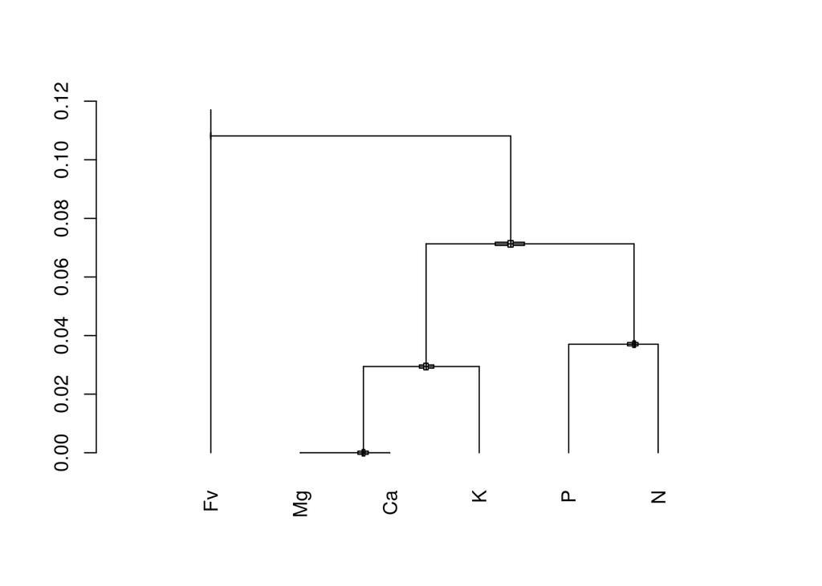

```r
psi <- gsi.buildilrBase(t(sbp))
isoLR <- ilr(comp, V = psi)
CoDaDendrogram(comp, V = psi)
```

Custom functions.

```r
source("scripts/ilrDefinition_1.2.R")
source("scripts/codadend_dev_1.4.R")

colnames(isoLR) <- ilrDefinition(sbp, side = "-+")
colnames(isoLR)
```

```
## [1] "[Fv | Mg,Ca,K,P,N]" "[Mg,Ca,K | P,N]"    "[P | N]"
## [4] "[Mg,Ca | K]"        "[Mg | Ca]"
```

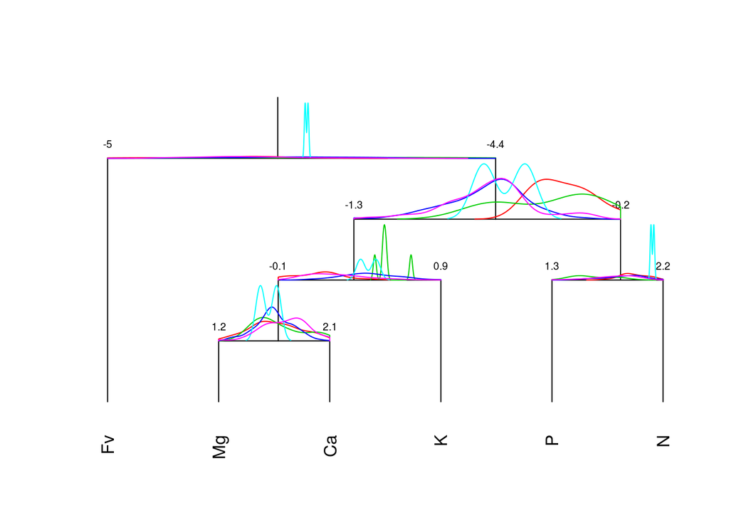

```r
CoDaDendrogram2(comp, V = psi,  equal.height = TRUE, show.range = TRUE, type = "density", group = data$Cultivar, range = "auto")
```

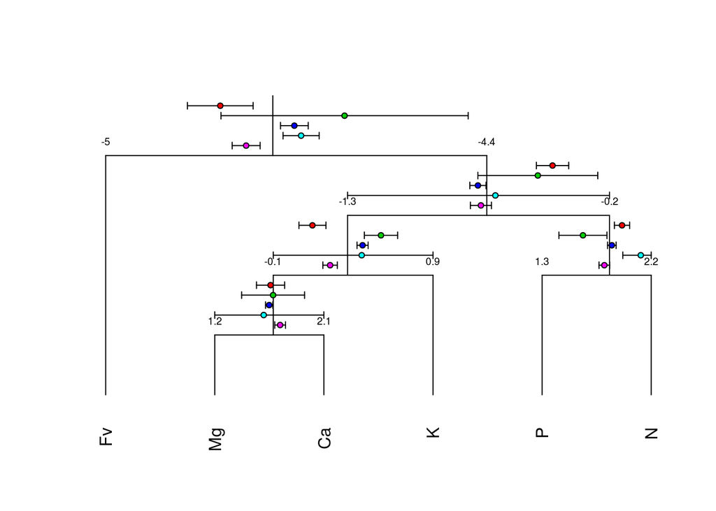

```r
CoDaDendrogram2(comp, V = psi,  equal.height = TRUE, show.range = TRUE, type = "conf", conf.level = 0.95, group = data$Cultivar, range = "auto")
```

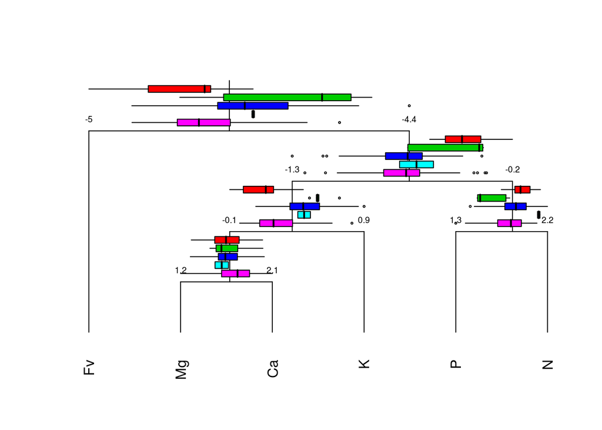

```r
CoDaDendrogram2(comp, V = psi,  equal.height = TRUE, show.range = TRUE, type = "boxplot", group = data$Cultivar, range = "auto")
```

Why label balances as [Denominator group | Numerator group] and not Numerator/Denominator? The positive balance leans toward the numerator and reversely. Conventionnaly, in 2D, the positive side is on the right and on top. Graphically, placing the numerator on the right seemed easier to interpret.

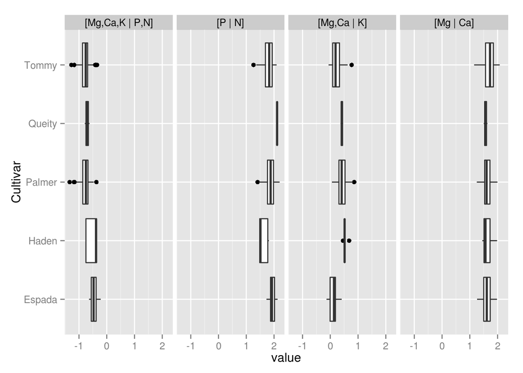

```r
library(ggplot2)
library(reshape2)
isoLR.df <- data.frame(Cultivar = data$Cultivar, isoLR[, -1])
colnames(isoLR.df) <- c('Cultivar', colnames(isoLR)[-1])
isoLR.gg <-  melt(isoLR.df, id = "Cultivar")

ggplot(isoLR.gg, aes(x = Cultivar, y = value)) +
  facet_grid(. ~ variable, scales = 'free') +
  geom_boxplot() +
  coord_flip()
```

### Outliers

As written previously, outliers are preferably detected across transformed data.

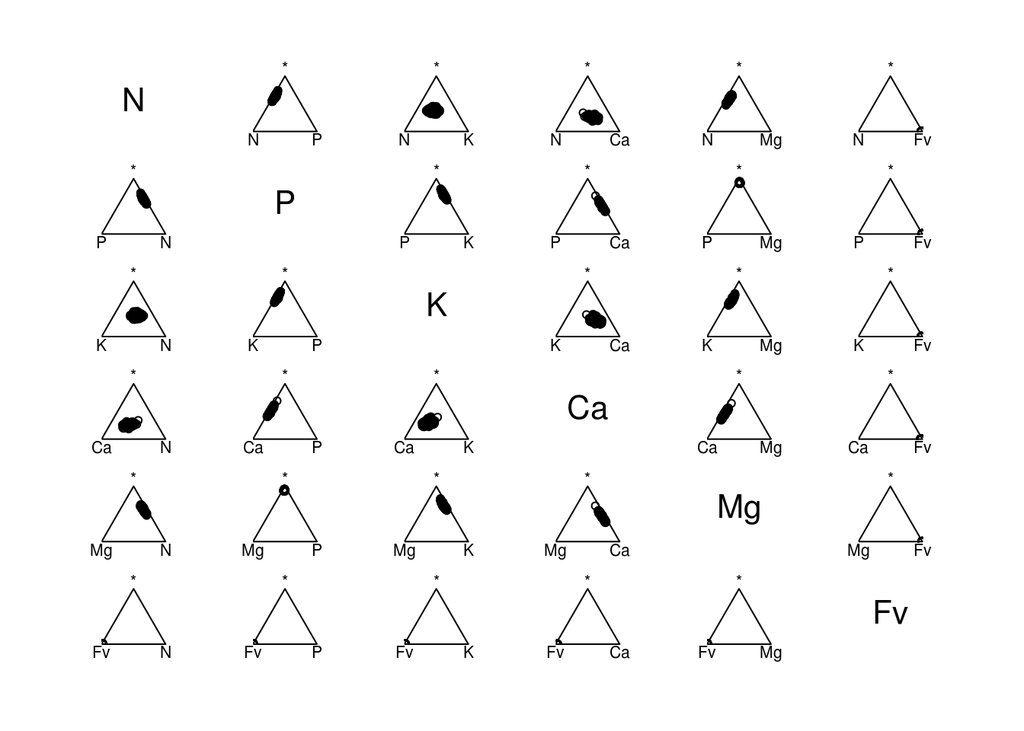

```r
plot(comp)
```

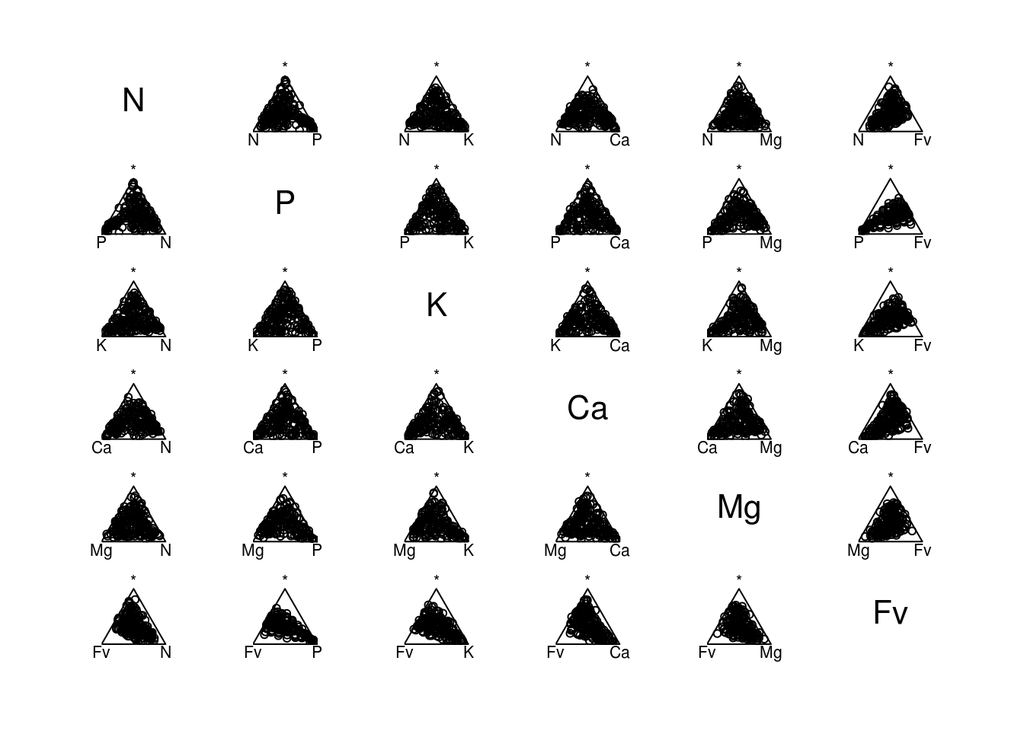

```r
plot(comp, center = TRUE, scale = TRUE)
```

```r
library(mvoutlier)
isIN <- sign1(partsNAZ, qcrit = 0.975)$wfinal01 # lower qcrit are more severe
sum(isIN == 1)/length(isIN)
```

```
## [1] 0.9491525
```

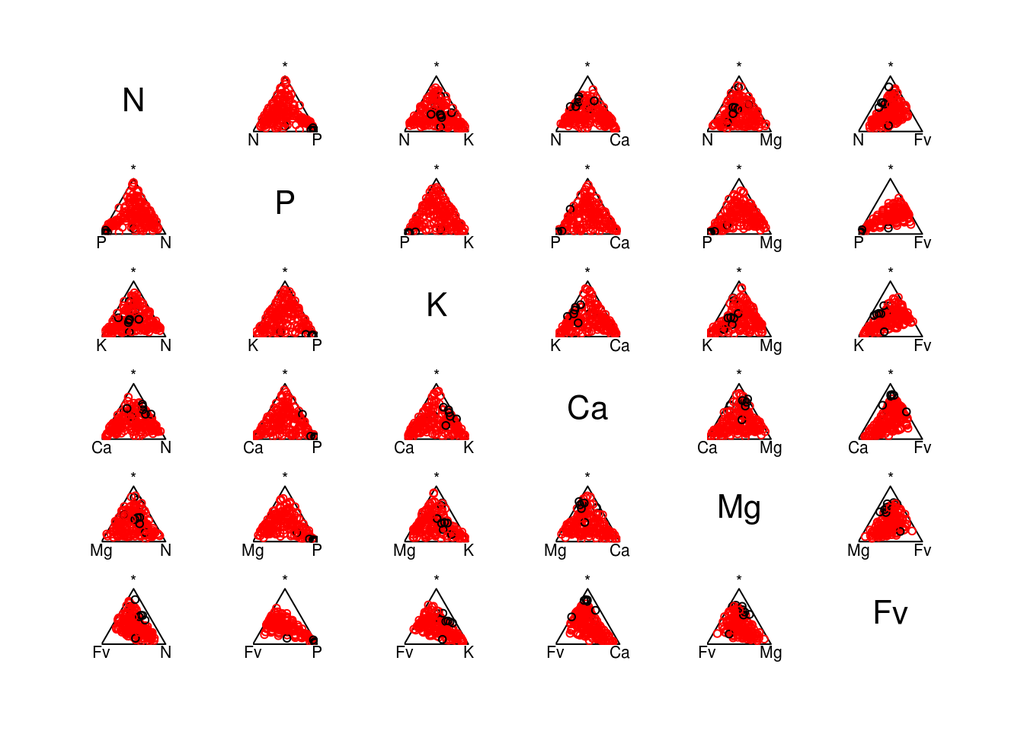

```r
plot(comp, center = TRUE, scale = TRUE, col = factor(isIN))
```

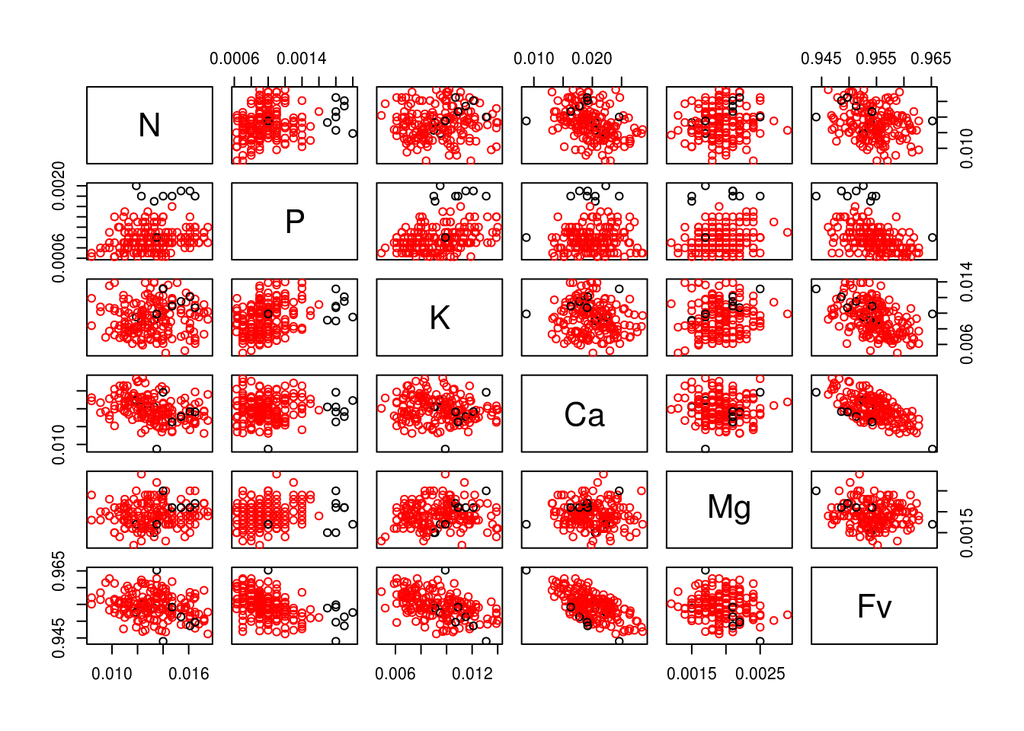

```r
plot(data.frame(comp), col = factor(isIN))
```

## Back transformations

```r
addLR_mean <- apply(addLR, 2, mean)
cenLR_mean <- apply(cenLR, 2, mean)
isoLR_mean <- apply(isoLR, 2, mean)

alrInv(addLR_mean)
```

[output not shown]

```r
clrInv(cenLR_mean)
```

```
##            N            P            K           Ca           Mg
## 0.0130826966 0.0009678515 0.0091624960 0.0196534146 0.0019099339
##           Fv
## 0.9552236074
## attr(,"class")
## [1] acomp
```

```r
ilrInv(isoLR_mean, V = psi)
```

```
##            N            P            K           Ca           Mg
## 0.0130826966 0.0009678515 0.0091624960 0.0196534146 0.0019099339
##           Fv
## 0.9552236074
## attr(,"class")
## [1] acomp
```

```r
mean(comp) # because comp has class acomp, mean is in fact mean.acomp, a special function from the compositions package
```

```
##            N            P            K           Ca           Mg
## 0.0130826966 0.0009678515 0.0091624960 0.0196534146 0.0019099339
##           Fv
## 0.9552236074
## attr(,"class")
## [1] acomp
```

```r
apply(partsNAZ, 2, mean) / 1000 # the biased mean
```

```
##  fol.N.g.kg  fol.P.g.kg  fol.K.g.kg fol.Ca.g.kg fol.Mg.g.kg          Fv
## 0.013227623 0.001000245 0.009379820 0.019944633 0.001929713 0.954517966
```

# Soils-specific applications of CoDa in `R`

```r
library(compositions)
data("ArcticLake")
```

## Ternary diagrams

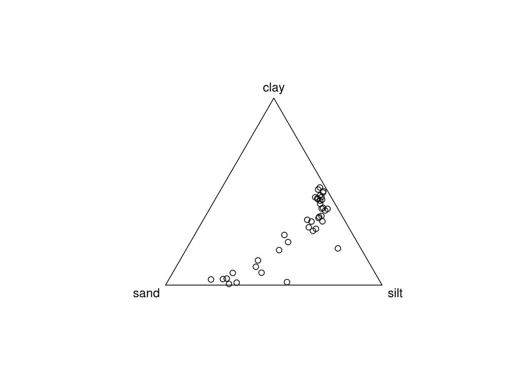

```r
plot(acomp(ArcticLake[, 1:3]))
```

```r
library(ggtern) # http://www.ggtern.com/
```

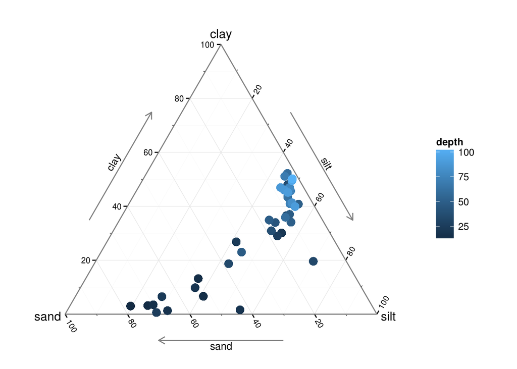

```r
aldf <- data.frame(ArcticLake) # ggplot (upon which ggtern is base) only work with data.frames

ggtern(data = aldf, aes(y = clay, x = sand, z = silt)) +
  theme_bw() + # publication friendly theme
  coord_tern(L="x",T="y",R="z") +
  geom_point(aes(colour = depth), size = 4)
```

```r
library(soiltexture)
alst <- aldf
colnames(alst) <- c('SAND', 'SILT', 'CLAY', 'DEPTH') # conform names
apply(alst[, 1:3], 1, sum) # not exactly summing to 1.
```

```
##     1     2     3     4     5     6     7     8     9    10    11    12
## 100.0 100.0 100.0  99.7 100.0 100.0 100.0 100.0 100.0 100.0 100.0 100.0
##    13    14    15    16    17    18    19    20    21    22    23    24
## 100.0 100.0 100.0 100.0 100.0 100.0 100.0 100.0 100.0 100.0 100.0 100.5
##    25    26    27    28    29    30    31    32    33    34    35    36
## 100.0 100.0 100.0 100.0 100.0  99.9 100.0 100.0 100.0  99.9  99.9 100.0
##    37    38    39
## 100.0 100.0 100.0
```

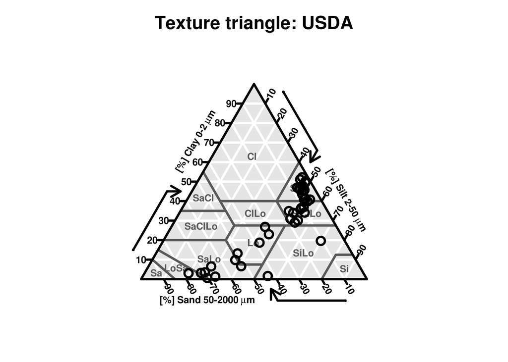

```r
alst[, 1:3] <- unclass(acomp(alst[, 1:3], total = 100))

TT.plot(class.sys = "USDA.TT",
        tri.data = alst,
        cex.lab = 0.8,
        cex.axis = 0.8)
```

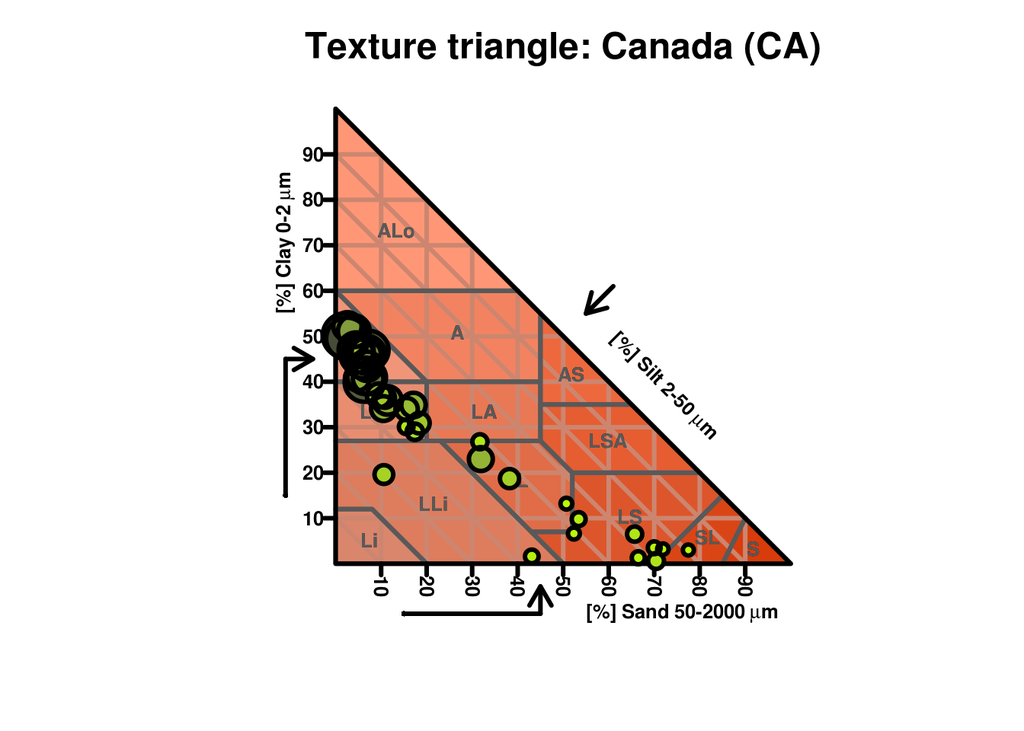

```r
TT.plot(class.sys = "CA.FR.TT",
        class.p.bg.col  = TRUE,
        tri.data = alst,
        z.name = 'DEPTH',
        cex.lab = 0.8,
        cex.axis = 0.8)
```

```r
textClass <- TT.points.in.classes(
  tri.data    = alst,
  class.sys   = "CA.EN.TT",
  PiC.type    = "t"
)

data.frame(ArcticLake, textClass)[1:15, ]
```

```
##    sand silt clay depth textClass
## 1  77.5 19.5  3.0  10.4      LoSa
## 2  71.9 24.9  3.2  11.7      SaLo
## 3  50.7 36.1 13.2  12.8         L
## 4  52.2 40.9  6.6  13.0      SaLo
## 5  70.0 26.5  3.5  15.7      SaLo
## 6  66.5 32.2  1.3  16.3      SaLo
## 7  43.1 55.3  1.6  18.0      SiLo
## 8  53.4 36.8  9.8  18.7      SaLo
## 9  15.5 54.4 30.1  20.7    SiClLo
## 10 31.7 41.5 26.8  22.1         L
## 11 65.7 27.8  6.5  22.4      SaLo
## 12 70.4 29.0  0.6  24.4      SaLo
## 13 17.4 53.6 29.0  25.8    SiClLo
## 14 10.6 69.8 19.6  32.5      SiLo
## 15 38.2 43.1 18.7  33.6         L
```

## Regression

How texture varies with the depth of the profile

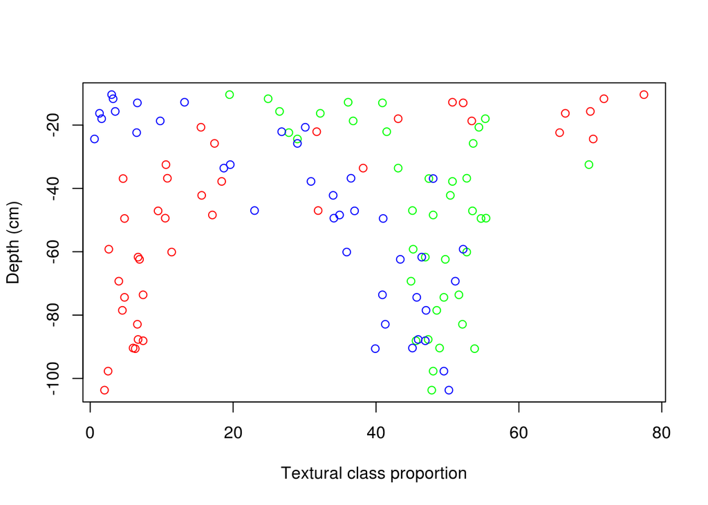

```r
plot(x = ArcticLake[, 1], y = -ArcticLake[, 4], col = 'red',
     xlab = "Textural class proportion",
     ylab = "Depth (cm)")
points(x = ArcticLake[, 2], y = -ArcticLake[, 4], col = 'green')
points(x = ArcticLake[, 3], y = -ArcticLake[, 4], col = 'blue')
```

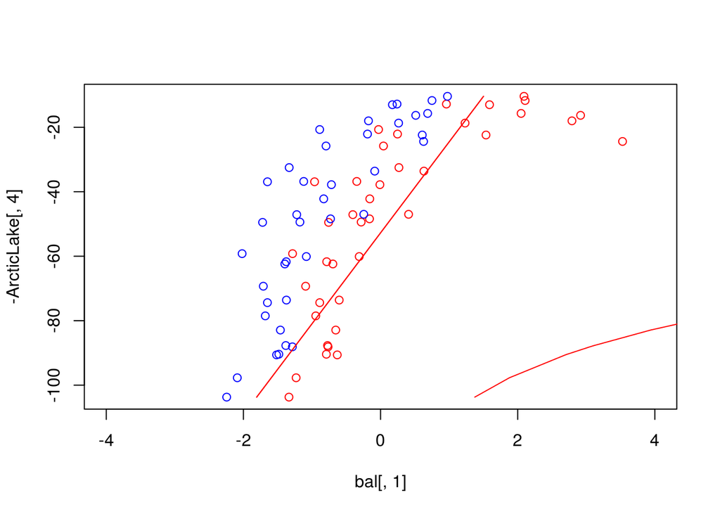

```r
comp <- acomp(ArcticLake[, 1:3])
sbp <- matrix(c(1, 1,-1,
                1,-1, 0),
              byrow = TRUE,
              ncol = 3)
psi <- gsi.buildilrBase(t(sbp))

bal <- ilr(comp, V = psi)

lm1 <- lm(bal[, 1] ~ ArcticLake[, 4])
lm2 <- lm(bal[, 2] ~ ArcticLake[, 4])

predBal1 <- predict(lm1)
predBal2 <- predict(lm2)

plot(bal[, 1], y = -ArcticLake[, 4], col = 'red', xlim = c(-4, 4))
points(bal[, 2], y = -ArcticLake[, 4], col = 'blue')
lines(predBal1, y = -ArcticLake[, 4], col = 'red')
lines(predBal1, y = -ArcticLake[, 4], col = 'red')

predComp <- unclass(ilrInv(cbind(predBal1, predBal2), V = psi)) * 100

lines(x = predComp[, 1], y = -ArcticLake[, 4], col = 'red')
lines(x = predComp[, 2], y = -ArcticLake[, 4], col = 'green')
lines(x = predComp[, 3], y = -ArcticLake[, 4], col = 'blue')
```

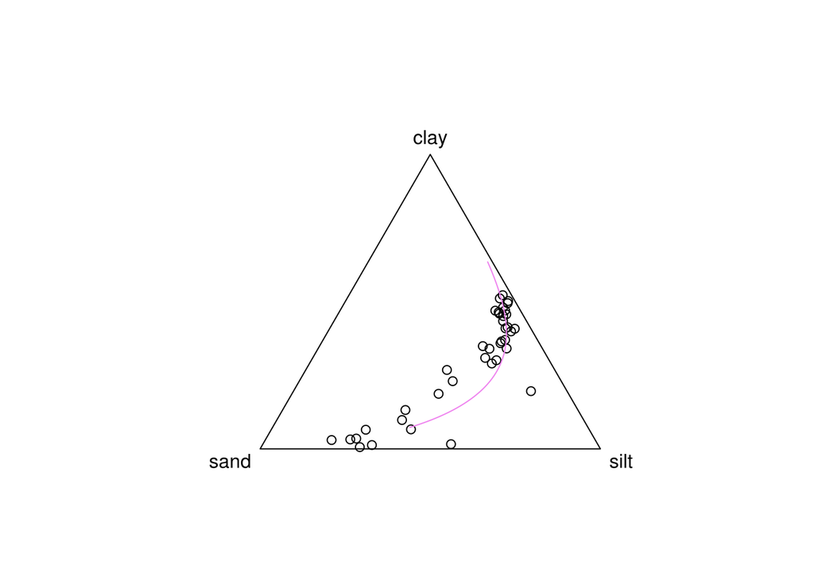

```r
plot(comp)
lines(acomp(predComp), col = 'violet')
```

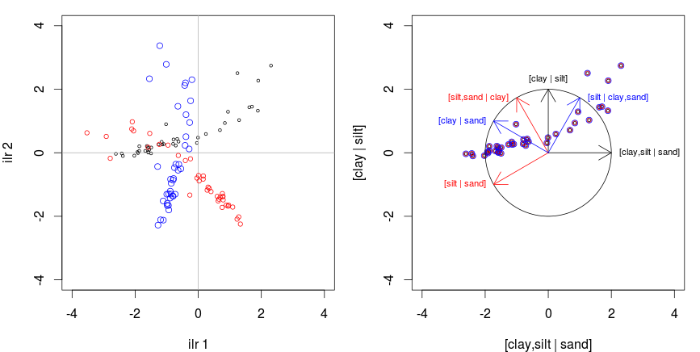

Source code: `scripts/ilr-sbp-rotation-axe.R`

## PCA

We use the Hydrochem dataset provided by the `R` compositions package, which, as described in the help file, “*contains a hydrochemical amount/compositional data set obtained from several rivers in the Llobregat river basin, in northeastern Spain.*”.

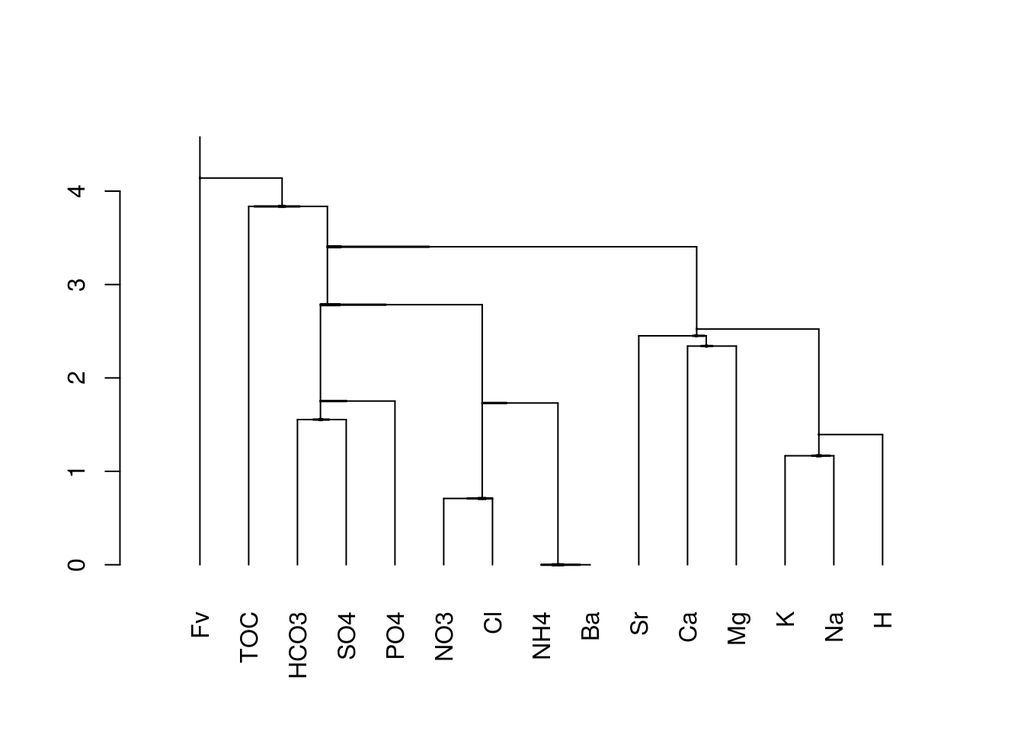

```r
library(compositions)
data("Hydrochem")

parts <- Hydrochem[, 6:19]
parts$Fv <- 1e6 - apply(parts[, 1:14], 1, sum)
comp <- acomp(parts)

sbp <- read.csv('data/sbpHydrochem.csv', sep = ';', header = TRUE)
psi <- gsi.buildilrBase(t(sbp))
bal <- ilr(comp, V = psi)
colnames(bal) <- ilrDefinition(sbp, side = '-+')
CoDaDendrogram(comp, V = psi)
```

Many axis reduction techniques can be applied to this dataset. The obviously most well-known and common axi reduction technique is the principal component analysis. The `base` package contain the necessary functions for PCA. But when it comes to plotting results and going further, I recommend the use of the `vegan` package.

```r
# install.packages("vegan")
library('vegan')
```

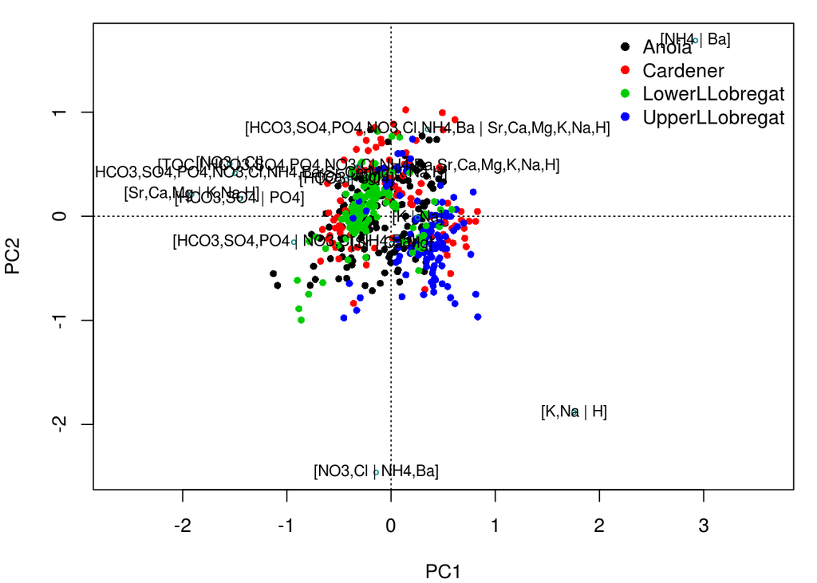

```r
pcaHydrochem <- rda(bal, scale = FALSE) # scale = FALSE: ilr are geometrically normalized.

scl <- 2 # Focus on the angle between descriptors
par(mar = c(4, 4, 1, 1))
plot(pcaHydrochem, type = "n", scaling = scl)
points(pcaHydrochem, display = "sites", col = Hydrochem$River, scaling = scl,
       pch = 16, cex = 0.8)
points(pcaHydrochem, display = "species", scaling = scl, cex = 0.5, col = "darkcyan")
text(pcaHydrochem, display = "species", scaling = scl, cex = 0.8, col = "black")
legend("topright", legend = levels(Hydrochem$River), bty = "n",
                      col = factor(levels(Hydrochem$River)), pch = 16)
```